# A Faculty’s Perspective on Our ISA Program, Job Opportunties and More

Fadel M. Megahed [^1]

Farmer School of Business, Miami University

October 23, 2020

# 1 An Overview of Our Faculty’s Expertise

## 1.1 Our Philosophy to Faculty Recruitment

If you were to Google for the skill-sets of today’s business analyst and/or data scientist, you will likely find a general consensus that such positions require cross-disciplinary training. An excellent visual depiction of such skills was provided by [Udeme Udofia in her medium article titled Discplines of Data Science](https://medium.com/@udemeudofia01/disciplines-in-data-science-a1da93306528). The image below is from her article:

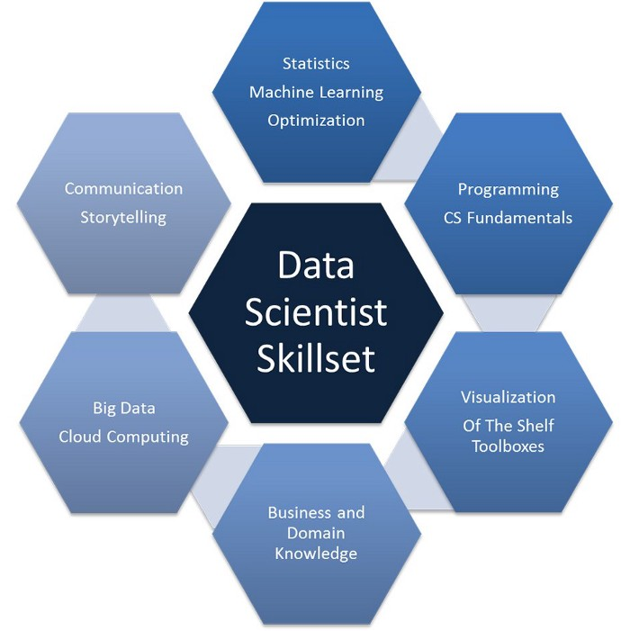

In the ISA department, we have embraced this philosophy, which was in part driven by observed needs and wants by our industry partners. Thus, our hires over the past five years were trained in a number of disciplines: (a) *Computer Science*, (b) *Industrial and Systems Engineering*, and (c) *Economics* in addition to those who were trained in *Information Technology and/or Business*. Furthermore, we have attempted to hire faculty who have had significant industry experiences whether it is through consulting arrangements or previous employment. For example, our most recent hire [Dr. Jon Michel came to us after serving as a Data Scientist at Google](https://miamioh.edu/fsb/directory/?up=/directory/michelj8).

## 1.2 Our Analytics Faculty’s Expertise

```r
pacman::p_load(tidyverse, magrittr, bibliometrix)

M = convert2df('savedrecs.txt')
```

```
##
## Converting your wos collection into a bibliographic dataframe
##
## Done!
##
##
## Generating affiliation field tag AU_UN from C1:  Done!
```

```r
NetMatrix = biblioNetwork(M, analysis = "co-occurrences", network = "keywords", sep = ";")
net=networkPlot(NetMatrix, normalize="association", weighted=T, n = 30, Title = "Frequent Keywords Used in Our Analytics Faculty's Research", type = "fruchterman", size=T,edgesize = 1,labelsize=0.7)
```

[figure not shown]

## 1.3 Relationship between Faculty Research and Pedagogy

Being on the cutting-edge of our fields, allows us to bring the latest technologies, problems and methodologies to our classroom. For example, if we use the latest research being done by Dr. Jones-Farmer and [myself]((https://miamioh.edu/fsb/directory/?up=/directory/megahefm) in the area of [COVID modeling](https://fmegahed.github.io/covid_analysis.html), this material was used to support learning outcomes during the current semester through:

- *ISA 401: Business Intelligence and Data Visualization*, where the students were asked to: (a) scrape both Miami University and the state of Ohio-related COVID data, (b) preprocess and analyze all [tweets made by President Trump on the Coronavirus](https://raw.githubusercontent.com/fmegahed/dataviz/master/Data/presidentTrumpTweetsCOVID.csv), and (c) develop dashboards for Coronavirus data.
- *ISA 444: Business Forecasting*. The students performed exploratory analysis of the time-series of confirmed COVID cases. You are encouraged to view our hands-on self-paced review materials for this class:
  - [Exam 1 - Self-Paced Review Material](http://rstudio.fsb.miamioh.edu:3838/megahefm/isa444/exam01/)
  - [Exam 2 - Self-Paced Review Material](http://rstudio.fsb.miamioh.edu:3838/megahefm/isa444/exam02/#section-welcome)
- *ISA 616: Communicating with Data*, where the students had access to the faculty’s GitHub repository and the processes used in communicating analytic results (and how it varies by audience).

# 2 On the Design of Our Analytics Programs

While you can find all our course offerings [here](https://bulletin.miamioh.edu/courses-instruction/isa/), our analytics programs were designed to cover the entire analytics spectrum from data collection and management $\longrightarrow$ descriptive analytics $\longrightarrow$ explanatory and predictive analytics $\longrightarrow$ prescriptive analytics.

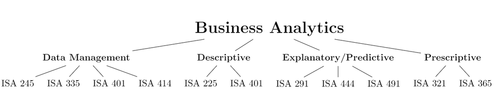

# 3 Careers in Analytics

## 3.1 Entry Level Jobs on Indeed as of 10/23/2020

### Total

[figure not shown]

### Total Number of $80,000+ Jobs

[figure not shown]

## 3.2 Sample Job Postings

### Forecast Analyst 1

[figure not shown]

### Forecast Analyst 2

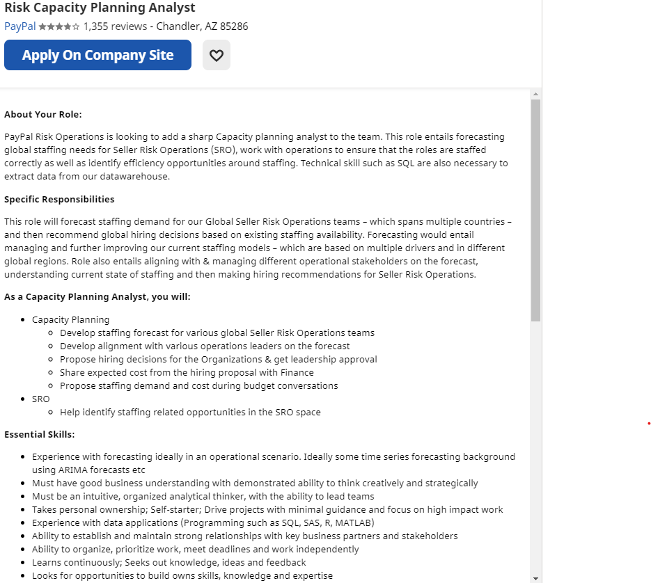

### Forecast Analyst 3

[figure not shown]

[^1]: Email: fmegahed@miamioh.edu | Phone: +1-513-529-4185 | Website: [Miami University Official](https://miamioh.edu/fsb/directory/?up=/directory/megahefm)